# Final Code Section

Ralchukwu Mogbogu

2024-02-16

# Instructions

You will need to complete the portion of the exam before starting the second portion. You will use your answers on this exam to complete the second half. Only knitted files will be graded! Make sure your complete this portion of the exam on your own. Use your notes and class examples to get started with the code.

# Abstract

Much attention has been devoted to how technological advancements have created a brave new workplace, revolutionizing the ways in which work is being carried out, and how employees can improve their productivity and efficiency. However, the advent of technology has also opened up new avenues and opportunities for individuals to misbehave. This study focused on cyberloafing—the act of employees using their companies’ internet access for personal purposes during work hours. Cyberloafing, thus, represents a form of production deviance. Using the theoretical frameworks offered by social exchange, organizational justice and neutralization, we examined the often-neglected dark side of the internet and the role that neutralization techniques play in facilitating this misbehavior at the workplace. Specifically, we developed a model, which suggested that when individuals perceived their organizations to be distributively, procedurally and interactionally unjust, they were likely to invoke the metaphor of the ledger as a neutralization technique to legitimize their subsequent engagement in the act of cyberloafing.

*Citation:* Lim, V. K. (2002). The IT way of loafing on the job: cyberloafing, neutralizing and organizational justice. Journal of Organizational Behavior, 23, 675-694. doi: 10.1002/job.161

# Method

Participants were given interviews to determine their perception of the company. After their interview the amount of cyberloafing (minutes per day) was measured using different types of computer stations. All employees were measured at each type of station.

# Dataset:

- Gender of the worker: male or female
- Perception of company: unjust, neutral, fair
- Cyberloafing: a measure of the amount of cyberloafing for several months
- Workstation distance: distance of workstation from boss
- Length of time: time spent working at current job

In this section, the data will be loaded for you from the package. You will change the id = 123456 to your HU id number. This number will generate your data for you in the same time each way, so if you rerun this analysis, you will get the same numbers each time.

```r
library(learnSTATS)
library(skimr)
library(mice)
```

```r
library(ggplot2)
library(dplyr)
library(Hmisc)
library(MeMoBootR)
library(corrplot)
library(cocor)
library(reshape)
library(pwr)
library(MOTE)
library(ez)
```

```r
final <- final_data(idnum = 285166)
#CHANGE ID


summary(final)
```

```
##     gender           perception         cyberloafing       distance
##  Length:396         Length:396         Min.   : 3.376   Min.   : 0.7143
##  Class :character   Class :character   1st Qu.:13.109   1st Qu.: 7.0471
##  Mode  :character   Mode  :character   Median :20.870   Median : 9.4123
##                                        Mean   :23.313   Mean   : 9.1124
##                                        3rd Qu.:32.273   3rd Qu.:11.2117
##                                        Max.   :68.017   Max.   :16.9921
##      length
##  Min.   : 0.7316
##  1st Qu.:14.5634
##  Median :20.0634
##  Mean   :20.1510
##  3rd Qu.:25.7123
##  Max.   :46.7775
```

```r
str(final)
```

```
## 'data.frame':    396 obs. of  5 variables:
##  $ gender      : chr  "female" "female" "female" "female" ...
##  $ perception  : chr  "fair" "fair" "fair" "fair" ...
##  $ cyberloafing: num  10.77 9.05 13.59 13.44 16.15 ...
##  $ distance    : num  6.19 5.5 4.55 8.21 9.82 ...
##  $ length      : num  18.6 18.3 26.5 15.6 23.9 ...
```

```r
skim(final)
```

Data summary

| Name | final |
| --- | --- |
| Number of rows | 396 |
| Number of columns | 5 |
| _______________________ |  |
| Column type frequency: |  |
| character | 2 |
| numeric | 3 |
| ________________________ |  |
| Group variables | None |

**Variable type: character**

| skim_variable | n_missing | complete_rate | min | max | empty | n_unique | whitespace |
| --- | --- | --- | --- | --- | --- | --- | --- |
| gender | 0 | 1 | 4 | 6 | 0 | 2 | 0 |
| perception | 0 | 1 | 4 | 7 | 0 | 3 | 0 |

**Variable type: numeric**

| skim_variable | n_missing | complete_rate | mean | sd | p0 | p25 | p50 | p75 | p100 | hist |
| --- | --- | --- | --- | --- | --- | --- | --- | --- | --- | --- |
| cyberloafing | 0 | 1 | 23.31 | 12.57 | 3.38 | 13.11 | 20.87 | 32.27 | 68.02 | ▆▇▃▂▁ |
| distance | 0 | 1 | 9.11 | 3.15 | 0.71 | 7.05 | 9.41 | 11.21 | 16.99 | ▁▅▇▆▂ |
| length | 0 | 1 | 20.15 | 7.82 | 0.73 | 14.56 | 20.06 | 25.71 | 46.78 | ▂▇▇▂▁ |

```r
#Made a copy of the original dataset

copy_finalDf = final

copy_finalDf$index <- seq_len(nrow(copy_finalDf))
```

# Data Preprocessing and Data Screening

This section includes conducting the following procedures:

- Accuracy Checks
- Handle missing values
- Handle Outliers

```r
# handling categorical variables
## Fix accuracy errors
copy_finalDf$gender <- as.factor(copy_finalDf$gender)
copy_finalDf$perception <- as.factor(copy_finalDf$perception)

# handling continuous variables
## selecting only numerical variables
numerical_values <- copy_finalDf[, sapply(copy_finalDf, is.numeric)]
summary(numerical_values)
```

```
##   cyberloafing       distance           length            index
##  Min.   : 3.376   Min.   : 0.7143   Min.   : 0.7316   Min.   :  1.00
##  1st Qu.:13.109   1st Qu.: 7.0471   1st Qu.:14.5634   1st Qu.: 99.75
##  Median :20.870   Median : 9.4123   Median :20.0634   Median :198.50
##  Mean   :23.313   Mean   : 9.1124   Mean   :20.1510   Mean   :198.50
##  3rd Qu.:32.273   3rd Qu.:11.2117   3rd Qu.:25.7123   3rd Qu.:297.25
##  Max.   :68.017   Max.   :16.9921   Max.   :46.7775   Max.   :396.00
```

```r
# selecting only nonnumeric variables
char_factor_values <- copy_finalDf[, sapply(copy_finalDf, function(x) is.character(x) || is.factor(x))]
char_factor_values$index <- seq_len(nrow(char_factor_values))
```

**Summary:**

For the first part of the preprocessing, I fixed data type issues from chr to factors for gender and perception since gender had two levels, female and male, and perception had three levels: fair, neutral, and unjust. The next part of the preprocessing involves handling missing values and outliers.

```r
#Check for missing values

apply(copy_finalDf ,2,function(x) sum(is.na(x)))
```

```
##       gender   perception cyberloafing     distance       length        index
##            0            0            0            0            0            0
```

```r
cat("Missing data: ")
```

```
## Missing data:
```

```r
table(apply(copy_finalDf,1,function(x){sum(is.na(x))/length(x)*100}))
```

```
##
##   0
## 396
```

**Summary:**

For handling missing values, no missing values in data it seems. Dataset is intact and does not have any missing values to be handled or imputed. Therefore, I skipped the accuracy check as dataset proves complete. I proceeded to then directly check for outliers and other neccesary data quality checks.

```r
##Handle outliers
# Removing the factor variables - the categorical variables

final_outlier <- numerical_values

summary(numerical_values)
```

```
##   cyberloafing       distance           length            index
##  Min.   : 3.376   Min.   : 0.7143   Min.   : 0.7316   Min.   :  1.00
##  1st Qu.:13.109   1st Qu.: 7.0471   1st Qu.:14.5634   1st Qu.: 99.75
##  Median :20.870   Median : 9.4123   Median :20.0634   Median :198.50
##  Mean   :23.313   Mean   : 9.1124   Mean   :20.1510   Mean   :198.50
##  3rd Qu.:32.273   3rd Qu.:11.2117   3rd Qu.:25.7123   3rd Qu.:297.25
##  Max.   :68.017   Max.   :16.9921   Max.   :46.7775   Max.   :396.00
```

```r
cat("Checking for Outlier via boxplot:::::: BEFORE")
```

```
## Checking for Outlier via boxplot:::::: BEFORE
```

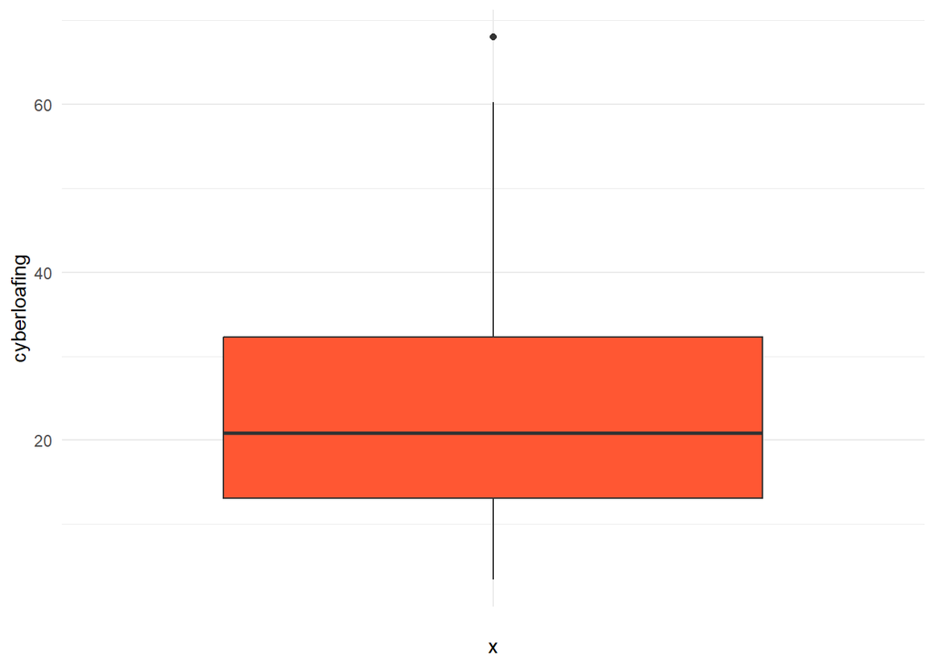

```r
# checking for outlier
ggplot(final_outlier) +
  aes(x = "", y = cyberloafing) +
  geom_boxplot(fill = "#ff5733") +
  theme_minimal()
```

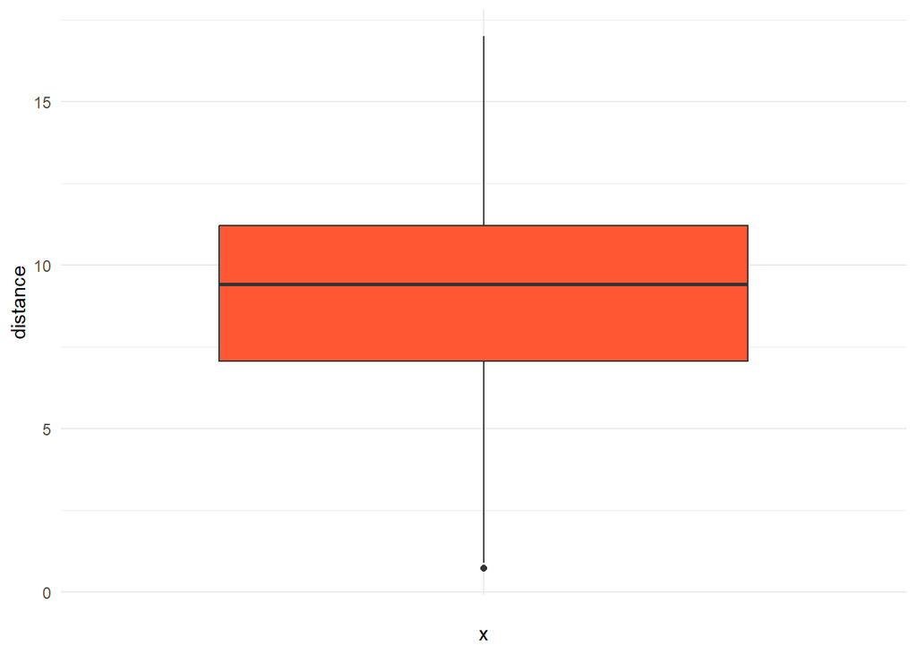

```r
ggplot(final_outlier) +
  aes(x = "", y = distance) +
  geom_boxplot(fill = "#ff5733") +
  theme_minimal()
```

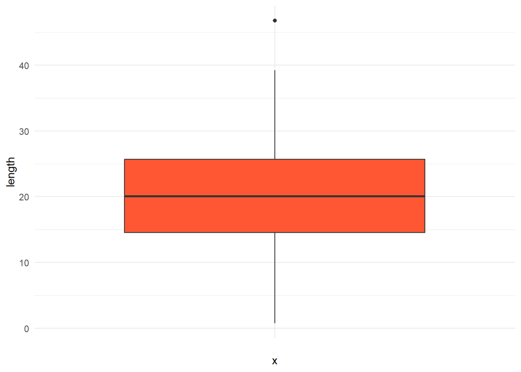

```r
ggplot(final_outlier) +
  aes(x = "", y = length) +
  geom_boxplot(fill = "#ff5733") +
  theme_minimal()
```

```r
# cyberloafing

cyberloafing_top <- boxplot.stats(final_outlier$cyberloafing)$out

lowerbound <- quantile(final_outlier$cyberloafing, 0.01)
upperbound <- quantile(final_outlier$cyberloafing, 0.99)

print(lowerbound)
```

```
##       1%
## 4.932771
```

```r
print(upperbound)
```

```
##      99%
## 56.28488
```

```r
outlierInd <- which(final_outlier$cyberloafing < lowerbound | final_outlier$cyberloafing > upperbound)
outlierInd
```

```
## [1]  75  78  83 119 281 284 320 325
```

```r
final_outlier[outlierInd, "cyberloafing"]
```

```
## [1]  3.376277  4.624860  4.696170  4.243887 60.234814 58.410056 68.017145
## [8] 58.954142
```

```r
final_outlier[outlierInd, ]
```

```
##     cyberloafing  distance     length index
## 75      3.376277  7.481303  0.8392758    75
## 78      4.624860  3.288290 13.4186452    78
## 83      4.696170  7.380176  2.9385405    83
## 119     4.243887  6.678108  4.3425019   119
## 281    60.234814 13.051804 36.2561798   281
## 284    58.410056 13.052626 36.8115043   284
## 320    68.017145 14.484402 39.2202846   320
## 325    58.954142 12.162836 38.7892535   325
```

```r
subset(final_outlier, cyberloafing != cyberloafing_top)
```

```
##     cyberloafing   distance     length index
## 1      10.769331  6.1874964 18.6174422     1
## 2       9.046459  5.4975568 18.3032922     2
## 3      13.591460  4.5481794 26.5011560     3
## 4      13.441280  8.2051202 15.6153109     4
## 5      16.150845  9.8151000 23.9491470     5
## 6       8.495608 10.5936041  8.0825618     6
## 7      11.102070  1.1444028 26.3735097     7
## 8      18.087513 11.2863761 15.1286822     8
## 9       9.787123  0.8979873 26.6833820     9
## 10     10.462724  1.0232870 21.8695438    10
## 11      8.612290  2.0335517 23.1479118    11
## 12     11.690111  8.7239457 12.0318907    12
## 13     14.095411  2.5197441 27.0728481    13
## 14     10.906823  7.7352308 14.0782278    14
```

[output cut: 381 more lines]

```r
iqr <- IQR(final_outlier$cyberloafing)
upper <- quantile(final_outlier$cyberloafing, 0.75) + 1.5*iqr
lower <- quantile(final_outlier$cyberloafing, 0.25) - 1.5*iqr

cyberloaf_noOutlier_df<- subset(final_outlier, final_outlier$cyberloafing > lower & final_outlier$cyberloafing < upper)


# distance

distance_top <- boxplot.stats(cyberloaf_noOutlier_df$distance)$out

distance_lowerbound <- quantile(cyberloaf_noOutlier_df$distance, 0.01)
distance_upperbound <- quantile(cyberloaf_noOutlier_df$distance, 0.99)

print(distance_lowerbound)
```

```
##       1%
## 1.137136
```

```r
print(distance_upperbound)
```

```
##      99%
## 15.85497
```

```r
outlierInd <- which(cyberloaf_noOutlier_df$distance < distance_lowerbound | cyberloaf_noOutlier_df$distance > distance_upperbound)
outlierInd
```

```
## [1]   9  10  64  92 135 275 330 347
```

```r
cyberloaf_noOutlier_df[outlierInd, "distance"]
```

```
## [1]  0.8979873  1.0232870  0.7142710  0.9243974 16.8835924 16.9921162 16.2741421
## [8] 15.9050753
```

```r
cyberloaf_noOutlier_df[outlierInd, ]
```

```
##     cyberloafing   distance    length index
## 9       9.787123  0.8979873 26.683382     9
## 10     10.462724  1.0232870 21.869544    10
## 64      8.190181  0.7142710 23.009692    64
## 92     12.326651  0.9243974 27.759847    92
## 135    20.722303 16.8835924  4.566239   135
## 275    46.142892 16.9921162 19.765088   275
## 331    46.880069 16.2741421 22.685672   331
## 348    39.803342 15.9050753 18.472363   348
```

```r
subset(cyberloaf_noOutlier_df, distance != 0.714271)
```

```
##     cyberloafing   distance     length index
## 1      10.769331  6.1874964 18.6174422     1
## 2       9.046459  5.4975568 18.3032922     2
## 3      13.591460  4.5481794 26.5011560     3
## 4      13.441280  8.2051202 15.6153109     4
## 5      16.150845  9.8151000 23.9491470     5
## 6       8.495608 10.5936041  8.0825618     6
## 7      11.102070  1.1444028 26.3735097     7
## 8      18.087513 11.2863761 15.1286822     8
## 9       9.787123  0.8979873 26.6833820     9
## 10     10.462724  1.0232870 21.8695438    10
## 11      8.612290  2.0335517 23.1479118    11
## 12     11.690111  8.7239457 12.0318907    12
## 13     14.095411  2.5197441 27.0728481    13
## 14     10.906823  7.7352308 14.0782278    14
```

[output cut: 381 more lines]

```r
iqr <- IQR(cyberloaf_noOutlier_df$distance)
upper <- quantile(cyberloaf_noOutlier_df$distance, 0.75) + 1.5*iqr
lower <- quantile(cyberloaf_noOutlier_df$distance, 0.25) - 1.5*iqr


dist_noOutlier_df<- subset(cyberloaf_noOutlier_df, cyberloaf_noOutlier_df$distance > lower & cyberloaf_noOutlier_df$distance < upper)


# length

length_top <- boxplot.stats(dist_noOutlier_df$length)$out
length_top
```

```
## [1] 46.77754
```

```r
length_lowerbound <- quantile(dist_noOutlier_df$length, 0.01)
length_upperbound <- quantile(dist_noOutlier_df$length, 0.99)

print(length_lowerbound)
```

```
##       1%
## 2.978655
```

```r
print(length_upperbound)
```

```
##      99%
## 37.43496
```

```r
outlierInd <- which(dist_noOutlier_df$length < length_lowerbound | dist_noOutlier_df$length > length_upperbound)
outlierInd
```

```
## [1]  44  53  74  82 189 268 310 323
```

```r
dist_noOutlier_df[outlierInd, "length"]
```

```
## [1]  0.7315789  1.0912402  0.8392758  2.9385405 38.9846145 46.7775442 37.8941914
## [8] 38.7892535
```

```r
dist_noOutlier_df[outlierInd, ]
```

```
##     cyberloafing  distance     length index
## 44     13.635214 14.520379  0.7315789    44
## 53     16.668597 15.796909  1.0912402    53
## 75      3.376277  7.481303  0.8392758    75
## 83      4.696170  7.380176  2.9385405    83
## 190    19.594194  1.171815 38.9846145   190
## 269    54.081670  7.260119 46.7775442   269
## 311    51.890659 10.859426 37.8941914   311
## 325    58.954142 12.162836 38.7892535   325
```

```r
subset(dist_noOutlier_df, length !=  46.77754)
```

```
##     cyberloafing   distance     length index
## 1      10.769331  6.1874964 18.6174422     1
## 2       9.046459  5.4975568 18.3032922     2
## 3      13.591460  4.5481794 26.5011560     3
## 4      13.441280  8.2051202 15.6153109     4
## 5      16.150845  9.8151000 23.9491470     5
## 6       8.495608 10.5936041  8.0825618     6
## 7      11.102070  1.1444028 26.3735097     7
## 8      18.087513 11.2863761 15.1286822     8
## 9       9.787123  0.8979873 26.6833820     9
## 10     10.462724  1.0232870 21.8695438    10
## 11      8.612290  2.0335517 23.1479118    11
## 12     11.690111  8.7239457 12.0318907    12
## 13     14.095411  2.5197441 27.0728481    13
## 14     10.906823  7.7352308 14.0782278    14
```

[output cut: 380 more lines]

```r
iqr <- IQR(dist_noOutlier_df$length)
upper <- quantile(dist_noOutlier_df$length, 0.75) + 1.5*iqr
lower <- quantile(dist_noOutlier_df$length, 0.25) - 1.5*iqr


final_noOutlier_df<- subset(dist_noOutlier_df, dist_noOutlier_df$length > lower & dist_noOutlier_df$length < upper)

rm(cyberloaf_noOutlier_df, dist_noOutlier_df, cyberloafing_top, lowerbound, upperbound,
   outlierInd, iqr, upper, lower, distance_top, distance_lowerbound, distance_upperbound, length_top,
   length_lowerbound, length_upperbound)

cat("Checking for Outlier via boxplot:::::: AFTER")
```

```
## Checking for Outlier via boxplot:::::: AFTER
```

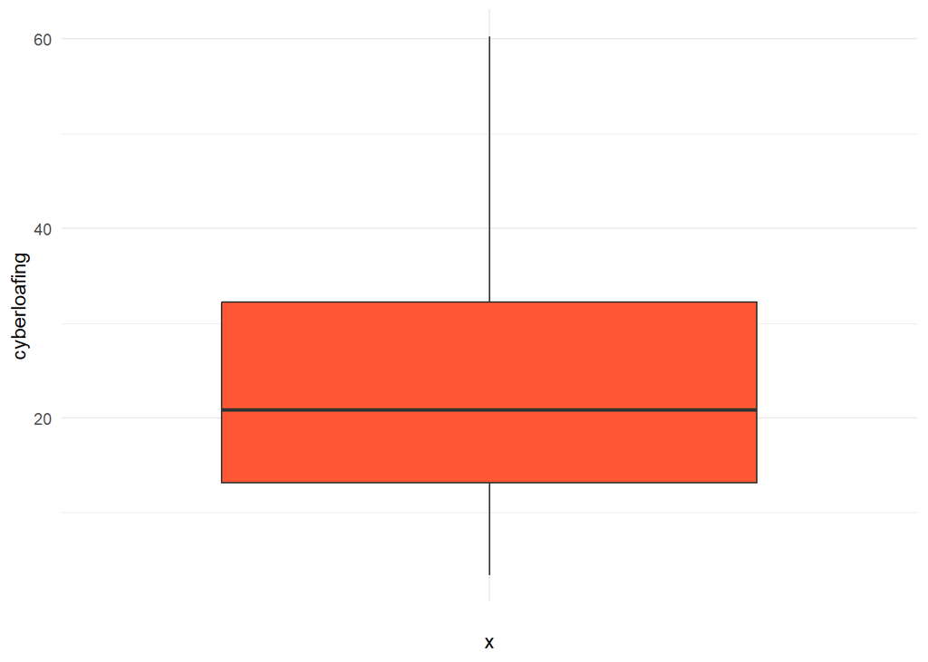

```r
# checking for outlier
ggplot(final_noOutlier_df) +
  aes(x = "", y = cyberloafing) +
  geom_boxplot(fill = "#ff5733") +
  theme_minimal()
```

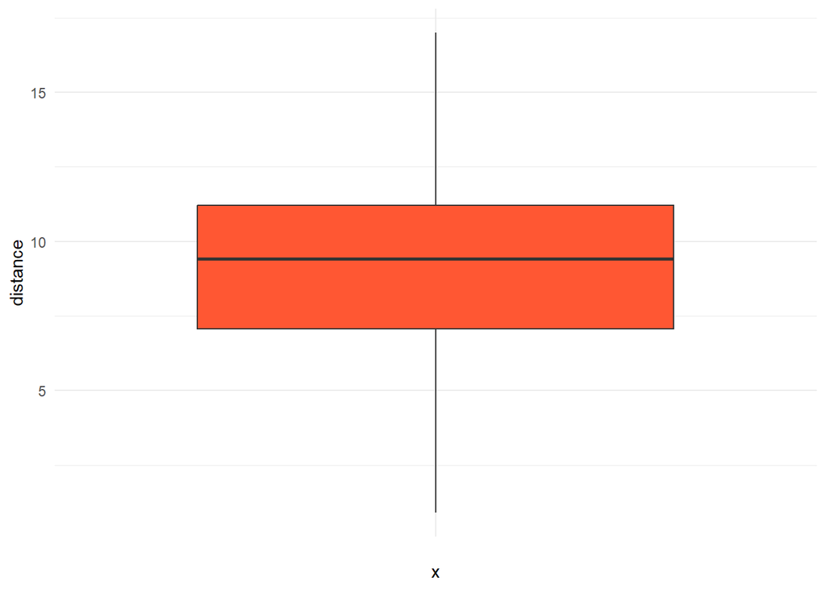

```r
# checking for outlier
ggplot(final_noOutlier_df) +
  aes(x = "", y = distance) +
  geom_boxplot(fill = "#ff5733") +
  theme_minimal()
```

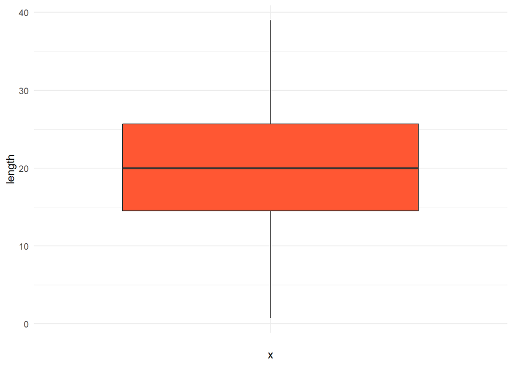

```r
# checking for outlier
ggplot(final_noOutlier_df) +
  aes(x = "", y = length) +
  geom_boxplot(fill = "#ff5733") +
  theme_minimal()
```

```r
cyberloaf_DF <- merge(char_factor_values, final_noOutlier_df, by = "index", all.x = FALSE)
```

**Summary:**

# One-way ANOVA

- Are there differences in cyberloafing based on the perception of the company? Use a one-way ANOVA to determine if there are group differences.
  - Run the ANOVA using the `ez` library.
  - Do you see overall group differences?
  - Can you assume homogeneity?

```r
cyberloaf_DF$ID <- as.factor(1:nrow(cyberloaf_DF))

one_wayAnova <- ezANOVA(data = cyberloaf_DF,
                        dv = cyberloafing,
                        between = perception,
                        wid = ID,
                        type = 3,
                        detailed = T)
```

```
## Coefficient covariances computed by hccm()
```

```r
print(one_wayAnova)
```

```
## $ANOVA
##        Effect DFn DFd       SSn      SSd         F             p p<.05
## 1 (Intercept)   1 390 211524.34 12781.41 6454.2559 9.722636e-245     *
## 2  perception   2 390  46493.26 12781.41  709.3258 1.184091e-130     *
##         ges
## 1 0.9430179
## 2 0.7843698
##
## $`Levene's Test for Homogeneity of Variance`
##   DFn DFd      SSn      SSd        F            p p<.05
## 1   2 390 1898.085 5088.142 72.74296 1.418165e-27     *
```

**Summary:**

One-way ANOVA is one of the powerful statistical tests used to form reasonable conclusions in research studies. One way ANOVA can be used in many ways: to compare mean and significant differences between two or more groups, understand their interactions and how they influence outcome variables and can be the initial step before you perform a post-hoc test.The overall difference will be based on their P-values and F-test for my output. I am also going to use theANOVA results to see if it meets the assumption of homogeneity based on the p-value.

To answer the question “Are there differences in cyberloafing based on the perception of the company?”, there is a difference in cyberloafing based on the perception of the company. We look at p-value < 0.05 and F-test (709.3258) to understand this. These values indicate that there isindeed a significant difference in cyberloafing between the different groups within perception (basicallythe different levels of perception: fair, unjust, neutral, etc.).

We cannot assume homogeneity because Levene’s Test for Homogeneity of Variance indicates a violation in the assumption for homogeneity( F-test value 72.74 with P-value < 0.05). This could be due to a few reasons. First, the groups within “perception” are not equal, violating the assumption of variance homogeneity. Second, effect size may be an added issue, especially since the result showed that we have a rather large effect size for the main effect of perception (0.784). Third, the Levene’s test shows that our p-value of 1.418165e-27 is extremely small. Violation of homogeneity may, in turn, affect the F-test’s reliability and P-value significance. Despite violating the assumption for homogeneity, even though the result shows the assumption was not met, we can still draw a conclusion from the one-way ANOVA. Based on the high F statistics and P value < 0.05, we can see a significant difference in cyberloafing based on perception.

# Post Hoc

- Run a post hoc test and correction on company perception.
- Where are the group differences in company perception? Indicate how the groups are different (i.e., higher, lower, same).

```r
##adjustment/correction via bonferonni
pairwise.t.test(cyberloaf_DF$cyberloafing,
                cyberloaf_DF$perception,
                p.adjust.method = "bonferroni",
                paired = F,
                var.equal = T)
```

```
##
##  Pairwise comparisons using t tests with pooled SD
##
## data:  cyberloaf_DF$cyberloafing and cyberloaf_DF$perception
##
##         fair   neutral
## neutral <2e-16 -
## unjust  <2e-16 <2e-16
##
## P value adjustment method: bonferroni
```

**Summary:**

I ran a post hoc test and correction on company perception. A post-hoc test is usually good to run, especially when your ANOVA reveals a statistically significant difference between tested variables. This test is also useful to show how the groups differ. Since I am running a post hoc and CORRECTION, I decided to use the Bonferroni correction. Post hoc corrects for type 1 error via p-value changes, and corrections adjust P values (increases, decreases, or same). The correction adjusts the significant level for the pairwise comparisons and post hoc corrections for type 1 errors via p-value changes (in order words, control type 1 error, which limits false positives).

# Correlations

- Include a correlation table of all the continuous variables with the `Hmisc` library.

```r
##all continous variables (all numberical variables/columns except columns 2 and 3 which are both categorical and then index and ID)
rcorr(as.matrix(na.omit (cyberloaf_DF[, -c(1, 2, 3, 7)])))
```

```
##              cyberloafing distance length
## cyberloafing         1.00     0.64   0.72
## distance             0.64     1.00  -0.01
## length               0.72    -0.01   1.00
##
## n= 393
##
##
## P
##              cyberloafing distance length
## cyberloafing              0.000    0.000
## distance     0.000                 0.845
## length       0.000        0.845
```

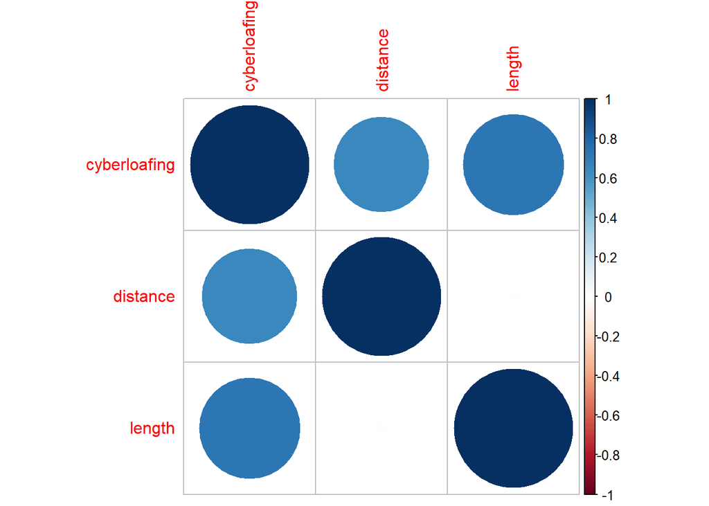

```r
# continuous measures for a visual representation
cor_matrix <- cor(cyberloaf_DF[, -c(1, 2, 3, 7)], use = "complete.obs")

corrplot(cor_matrix)
```

**Summary:**

For the correlation table, I included one of all the continuous variables with the “Hmisc” library already loaded at the start of the file, along with other libraries. The continuous variables for this study are the numerical ones. Therefore, the continuous variables here are cyberloafing, distance, and length. The code I used omits the use of unnecessary columns and categorical columns (1, 2, 3, and 7) for this correlation analysis. Using the same tactics, I coded to show a correlation plot/matrix for visualization representation. Regarding correlation, 1 (positive) and -1(negative) indicate a strong correlation. From the output, aside from the variables that may show a strong correlation with themselves (e.g., 1.00), the strongest correlation from this table is between cyberloafing and length at 0.72, which is closest to 1.00. Length and distance, on the other hand, are not correlated with each other. Therefore, there is a significant relationship between how much cyberloafing an employee does and how much time they have spent working at that current job.

- Calculate the difference in correlations for:
- 1. cyberloafing and distance
- 2. cyberloafing and length of time.
- Are these two correlations different?

```r
cocor(~cyberloafing + distance | cyberloafing + length, data = cyberloaf_DF)
```

```
##
##   Results of a comparison of two overlapping correlations based on dependent groups
##
## Comparison between r.jk (cyberloafing, distance) = 0.6424 and r.jh (cyberloafing, length) = 0.722
## Difference: r.jk - r.jh = -0.0795
## Related correlation: r.kh = -0.0099
## Data: cyberloaf_DF: j = cyberloafing, k = distance, h = length
## Group size: n = 393
## Null hypothesis: r.jk is equal to r.jh
## Alternative hypothesis: r.jk is not equal to r.jh (two-sided)
## Alpha: 0.05
##
## pearson1898: Pearson and Filon's z (1898)
##   z = -2.0255, p-value = 0.0428
##   Null hypothesis rejected
##
## hotelling1940: Hotelling's t (1940)
##   t = -4.6398, df = 390, p-value = 0.0000
##   Null hypothesis rejected
##
## williams1959: Williams' t (1959)
##   t = -2.0341, df = 390, p-value = 0.0426
##   Null hypothesis rejected
##
## olkin1967: Olkin's z (1967)
##   z = -2.0255, p-value = 0.0428
##   Null hypothesis rejected
##
## dunn1969: Dunn and Clark's z (1969)
##   z = -2.0301, p-value = 0.0423
##   Null hypothesis rejected
##
## hendrickson1970: Hendrickson, Stanley, and Hills' (1970) modification of Williams' t (1959)
##   t = -4.6397, df = 390, p-value = 0.0000
##   Null hypothesis rejected
##
## steiger1980: Steiger's (1980) modification of Dunn and Clark's z (1969) using average correlations
##   z = -2.0283, p-value = 0.0425
##   Null hypothesis rejected
##
## meng1992: Meng, Rosenthal, and Rubin's z (1992)
##   z = -2.0303, p-value = 0.0423
##   Null hypothesis rejected
##   95% confidence interval for r.jk - r.jh: -0.2937 -0.0052
##   Null hypothesis rejected (Interval does not include 0)
##
## hittner2003: Hittner, May, and Silver's (2003) modification of Dunn and Clark's z (1969) using a backtransformed average Fisher's (1921) Z procedure
##   z = -2.0319, p-value = 0.0422
##   Null hypothesis rejected
##
## zou2007: Zou's (2007) confidence interval
##   95% confidence interval for r.jk - r.jh: -0.1577 -0.0027
##   Null hypothesis rejected (Interval does not include 0)
```

**Summary:**

For the correlation differences, the output shows the “Results of a comparison of two overlapping correlations based on dependent groups.” From the output produced, we can see that cyberloafing is positively related to distance at 0.6424 (r.jk) and is also positively related to length at 0.722 (r.jh). The difference, which is -0.0795 (as shown via difference: r.jk - r.jh = -0.0795), means that the correlation between r.jk as compared to r.jh is lower by 0.0795, hence the negative direction of the difference. From the correlation, we can conclude that cyberloafing and distance have a weaker correlation than cyberloafing and length. So, the correlations for cyberloafing with both variables (length of time and distance) are different. Additionally, other tests also show the calculation of the difference, and via their confidence intervals, we can see that none include zero, so they are significant and reject the null hypothesis.

# Hierarchical Regression:

- Use a hierarchical regression predicting cyberloafing with the following steps:
  - Step 1: Gender
  - Step 2: Perception of Company
  - Step 3: Length of time, workstation distance
- Include the `summary()` at each step. Include an `anova()` on all three models to be able to examine the changes in each step.

```r
Step1 <- lm(cyberloafing ~ gender, data = cyberloaf_DF)
Step2 <- lm(cyberloafing ~ gender + perception, data = cyberloaf_DF)
Step3 <- lm(cyberloafing ~ gender + perception + length + distance, data = cyberloaf_DF)

summary(Step1)
```

```
##
## Call:
## lm(formula = cyberloafing ~ gender, data = cyberloaf_DF)
##
## Residuals:
##     Min      1Q  Median      3Q     Max
## -19.285 -10.335  -2.477   8.681  36.570
##
## Coefficients:
##             Estimate Std. Error t value Pr(>|t|)
## (Intercept)   23.665      0.881  26.862   <2e-16 ***
## gendermale    -1.003      1.241  -0.808     0.42
## ---
## Signif. codes:  0 '***' 0.001 '**' 0.01 '*' 0.05 '.' 0.1 ' ' 1
##
## Residual standard error: 12.3 on 391 degrees of freedom
## Multiple R-squared:  0.001667,   Adjusted R-squared:  -0.0008861
## F-statistic: 0.653 on 1 and 391 DF,  p-value: 0.4195
```

```r
summary(Step2)
```

```
##
## Call:
## lm(formula = cyberloafing ~ gender + perception, data = cyberloaf_DF)
##
## Residuals:
##      Min       1Q   Median       3Q      Max
## -21.2483  -2.5641  -0.4756   2.7767  22.2836
##
## Coefficients:
##                   Estimate Std. Error t value Pr(>|t|)
## (Intercept)        11.4524     0.5768  19.856   <2e-16 ***
## gendermale         -1.0856     0.5757  -1.886   0.0601 .
## perceptionneutral  10.3855     0.7037  14.758   <2e-16 ***
## perceptionunjust   26.4988     0.7064  37.512   <2e-16 ***
## ---
## Signif. codes:  0 '***' 0.001 '**' 0.01 '*' 0.05 '.' 0.1 ' ' 1
##
## Residual standard error: 5.706 on 389 degrees of freedom
## Multiple R-squared:  0.7863, Adjusted R-squared:  0.7847
## F-statistic: 477.2 on 3 and 389 DF,  p-value: < 2.2e-16
```

```r
summary(Step3)
```

```
##
## Call:
## lm(formula = cyberloafing ~ gender + perception + length + distance,
##     data = cyberloaf_DF)
##
## Residuals:
##      Min       1Q   Median       3Q      Max
## -11.6173  -1.3033  -0.1063   1.3012   9.0470
##
## Coefficients:
##                    Estimate Std. Error t value Pr(>|t|)
## (Intercept)       -22.37546    0.94231 -23.745  < 2e-16 ***
## gendermale          1.78880    0.27894   6.413 4.17e-10 ***
## perceptionneutral  -0.63264    0.44047  -1.436  0.15173
## perceptionunjust    2.05424    0.74172   2.770  0.00588 **
## length              1.09532    0.03390  32.311  < 2e-16 ***
## distance            2.43620    0.06755  36.063  < 2e-16 ***
## ---
## Signif. codes:  0 '***' 0.001 '**' 0.01 '*' 0.05 '.' 0.1 ' ' 1
##
## Residual standard error: 2.644 on 387 degrees of freedom
## Multiple R-squared:  0.9544, Adjusted R-squared:  0.9538
## F-statistic:  1619 on 5 and 387 DF,  p-value: < 2.2e-16
```

```r
anova(Step1, Step2, Step3)
```

```
## Analysis of Variance Table
##
## Model 1: cyberloafing ~ gender
## Model 2: cyberloafing ~ gender + perception
## Model 3: cyberloafing ~ gender + perception + length + distance
##   Res.Df   RSS Df Sum of Sq       F    Pr(>F)
## 1    391 59176
## 2    389 12666  2     46510 3326.84 < 2.2e-16 ***
## 3    387  2705  2      9960  712.46 < 2.2e-16 ***
## ---
## Signif. codes:  0 '***' 0.001 '**' 0.01 '*' 0.05 '.' 0.1 ' ' 1
```

**Summary:**

Hierarchical regression was performed on the variables in three (3) steps to predict cyberloafing changes within other variables. The steps of this regression analysis involve variables “gender,” “perception,” “length,” and “distance.” After that, we include “anova()” on all three models to examine the changes in each step.

To successfully examine the hierarchical regression output, it is important to check if the addition of steps added a significant amount of variance (check F tests and P values), and also check which predictors are significant based on their P values. With the code inputted, we went about it in 3 steps. First, we show the relationship between cyberloafing and gender, and we know this because in linear regression using R programming, the tilde (~) usually specifies a relationship between variables. So, as the step goes to the next, we are specifying the relationship between an outcome variable (cyberloafing) and a predictor variable (gender, perception, length, and distance). From the output, we see that the output changed gender into a “dummy” variable to indicate male and female cyberloafing scores. Therefore, it is safe to say that the estimate for the male gender is 1.003 less than that of the female gender in this study. Also, as per statistical significance, “gendermale” is not statistically significant at a P-value of 0.42, greater than the p-value of 0.05. Also, the overall summary for this step shows that the f-statistic is 0.653 with a p-value of 0.4195, further showing that the first model is not statistically significant at the 0.05 level.

The next model is the step 2 output. Model two shows if gender and perception influence (have an effect) cyberloafing. For this model, we see that perception is significant in step 2, with a p-value of <2e-16. Then, we move to the third model in step 3. We included length and distance in the formula to test the effect of cyberloafing. In step 3, we see a bit of a twist, “gendermale” becomes significant at an extremely small p-value of 4.17e-10. Then, for perception, only “perceptionunjust” is statistically significant at p-value 0.00588, while “perceptionneutral” is NOT significant at 0.15173. Please note that we are operating under the 0.05 significant level for p-value. Also, length (<;2e-16) and distance (<2e-16) are significant. Now that we have examined the summaries of all the models, we move on to the ANOVA part of this hierarchical regression.

From the ANOVA output of all the models/steps, we can see that adding each step came with a significant amount of variance. This is noticeable in step 2 (F: 3326.84, P: <2.2e-16) and especially in step 3 (F: 712.46, P: <2.2e-16). Most especially in step 3 because of the variation explained by predictors; additional predictors usually add more variance. Therefore, from all this, the predictor variables do indeed have an effect on the outcome variable. That is to say that we reject the null hypothesis based on the significance of each model with additional predictor variables. That is saying there is a sure effect on cyberloafing from other variables.

# Mediation or Moderation

- Using cyberloaf as the dependent variable, test either:
  - Mediation using distance as X and length of time as M - examining if length of time working for the company mediates the relationship between workstation distance and cyberloafing.
  - Moderation using distance as X and length of time as M - examining if length of time interacts with the workstation distance to predict cyberloafing.
  - Just one of these!
  - You can use the special package for this analysis, but be sure to include all portions of the analysis as output (mediation: models, Sobel, bootstrapping; moderation: models + simple slopes).

```r
output <- moderation1(y = "cyberloafing", x = "distance", m = "length",
                    df = cyberloaf_DF)
```

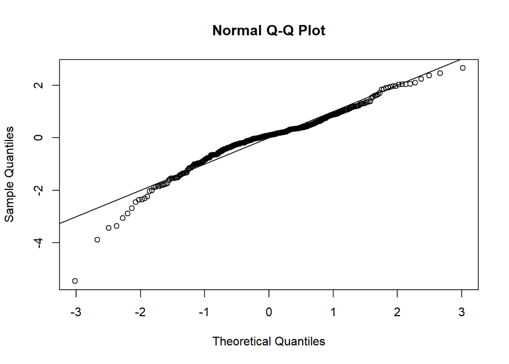

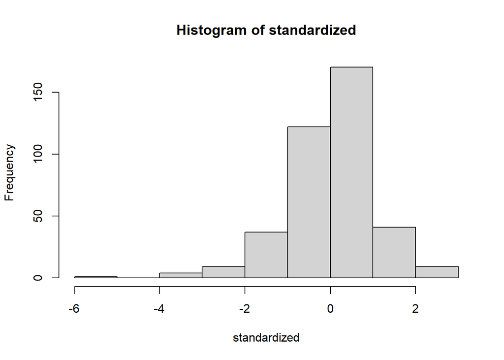

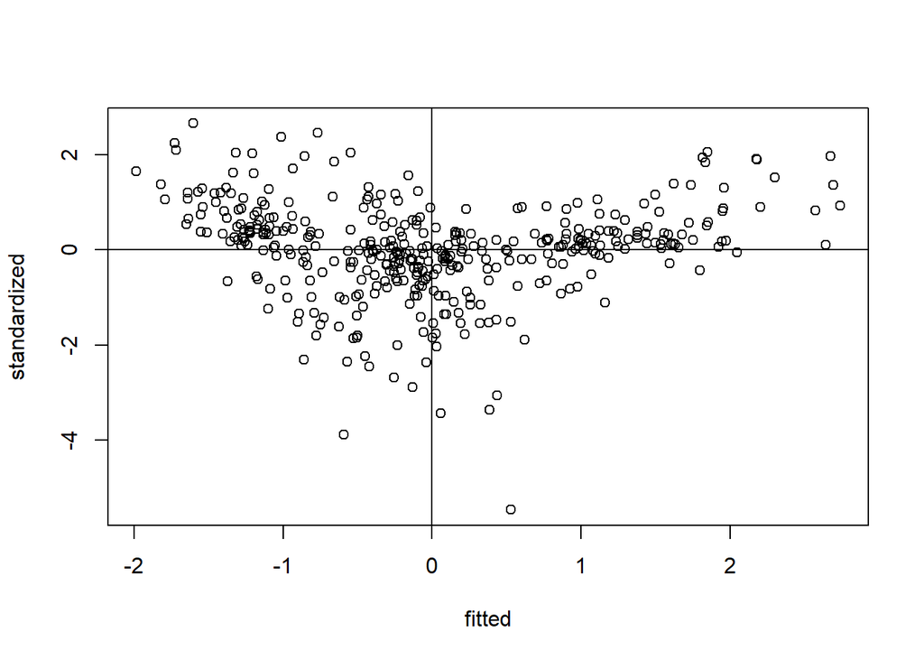

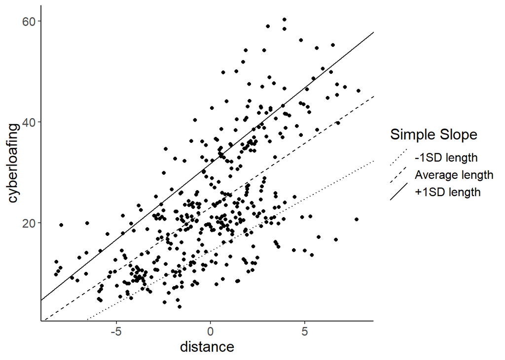

```r
output$graphslopes
```

```r
summary(output$model1)
```

```
##
## Call:
## lm(formula = allformulas$eq1, data = finaldata)
##
## Residuals:
##      Min       1Q   Median       3Q      Max
## -13.3676  -1.0733   0.2175   1.3080   6.6227
##
## Coefficients:
##                  Estimate Std. Error t value Pr(>|t|)
## (Intercept)     23.173668   0.128201  180.76   <2e-16 ***
## distance         2.530993   0.041246   61.36   <2e-16 ***
## length           1.130255   0.017027   66.38   <2e-16 ***
## distance:length  0.061022   0.005316   11.48   <2e-16 ***
## ---
## Signif. codes:  0 '***' 0.001 '**' 0.01 '*' 0.05 '.' 0.1 ' ' 1
##
## Residual standard error: 2.541 on 389 degrees of freedom
## Multiple R-squared:  0.9576, Adjusted R-squared:  0.9573
## F-statistic:  2930 on 3 and 389 DF,  p-value: < 2.2e-16
```

```r
##moderation: models + simple slopes
####assumption for linearity based on linear pattern
####evidence of moderation based on the slopes on the interaction model (note: if they are parallel on the graph, it shows no evidence for moderation and interaction term is not significant)
```

**Summary:**

I decided to go with Moderation since we had to pick either that or Mediation.